# SUN domain-containing protein 2

Fold-switch pair **4dxrA_4dxtA** — **4dxrA** vs **4dxtA**

Homo sapiens

## Figure 1: Phylogenetic tree with per-cluster fold-preference heatmap.

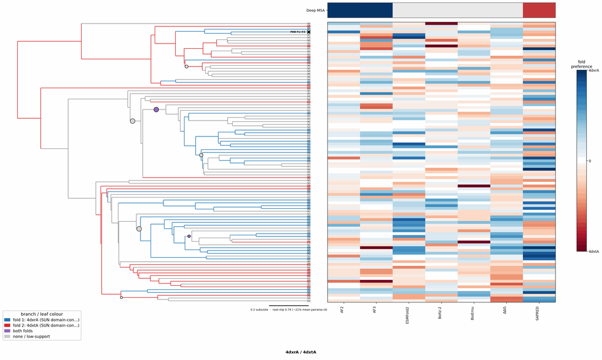

## Figure 2: Aligned overlay (both folds superposed)

The single fold-switching chain of each fold superposed by TM-align; waters hidden, any ligand shown as green sticks. Grey = structurally conserved core, colour = divergent (fold-switching) region.

4dxrA (SUN domain-containing protein 2) · dimer4dxtA (SUN domain-containing protein 2) · monomerLigand DMU (bound to 4dxrA)

TM-score: 0.929 · Trigger class: protein_binding

Aligned overlay

Loading...

## Figure 3: The two folds, side by side

Each fold is coloured by per-residue Cα deviation between the two superposed structures: grey ≈ conserved core, full colour = structurally divergent (fold-switching) region.

4dxrA (SUN domain-containing protein 2)

4dxtA (SUN domain-containing protein 2)

0 Å5≥10 Å

4dxrA (SUN domain-containing protein 2)

Loading...

4dxtA (SUN domain-containing protein 2)

Loading...

## Figure 4: Best-cluster predicted contact maps over the two true folds.

Predicted contact maps (MSA-Transformer) for the clusters best matching each fold, over the true contacts of fold 1 (upper triangle) and fold 2 (lower). Divergent contacts between clusters are the contact-level signature of fold-switching.

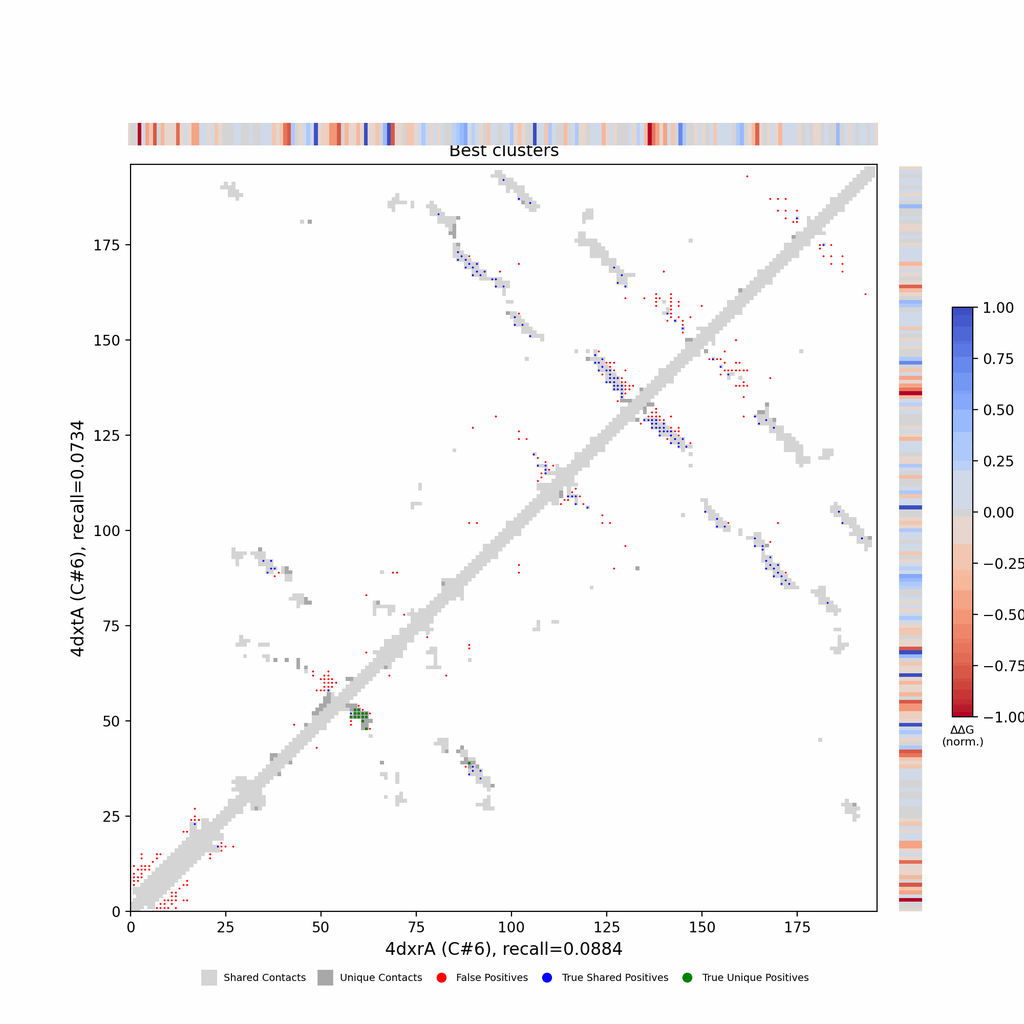

## Figure 5: Per-residue ΔΔG fold-preference contribution

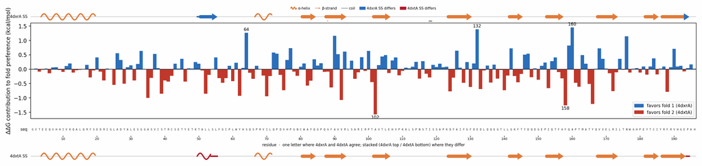

**More figures**

## Figure 6: Deep-MSA contact map panel / Best clusters contact map panel

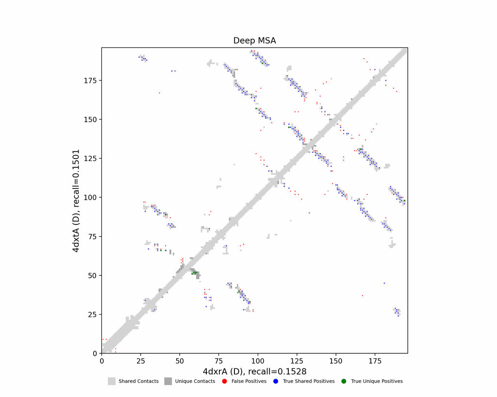

Deep-MSA contact map panel

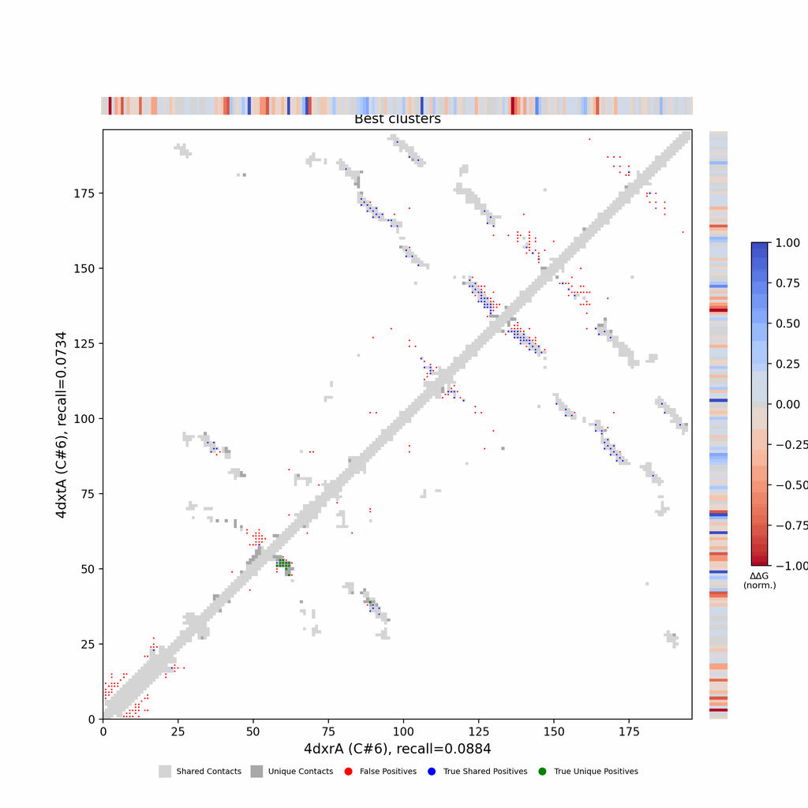

Best clusters contact map panel

## Figure 7: All clusters contact-map mosaic (small multiples).

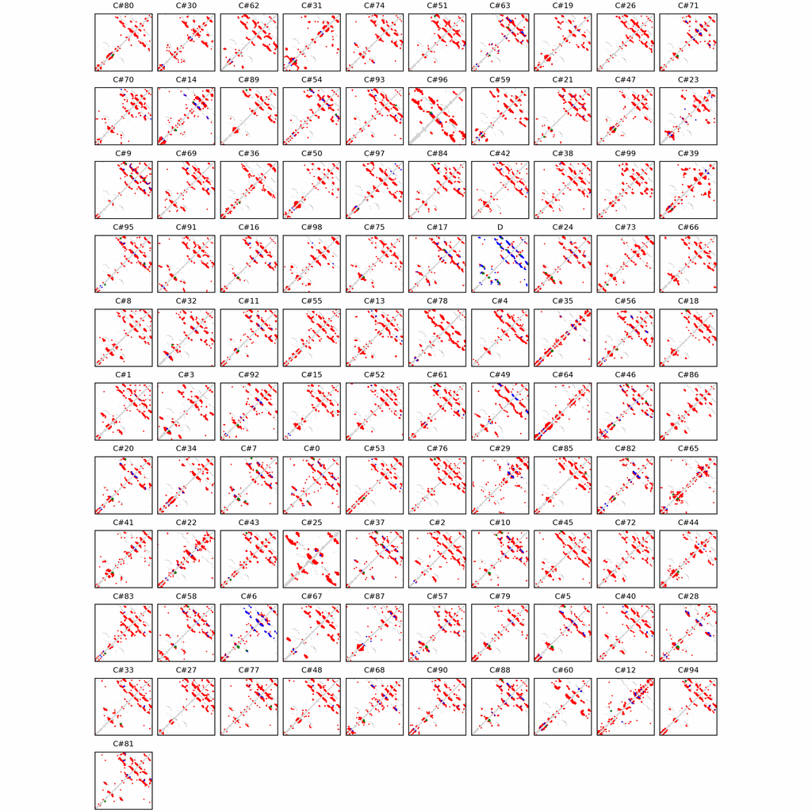

## Figure 8: Phylo null: tree with shuffled cluster fold labels.

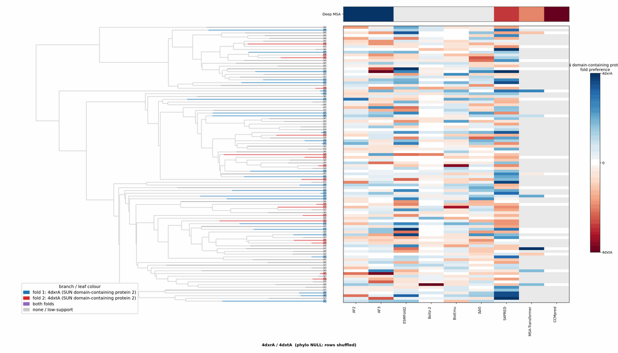

## Cluster metrics table

Per-cluster metrics underlying the figures above.

| cluster | n | neff | AF2_TM1 | AF2_TM2 | AF3_TM1 | AF3_TM2 | RE-MSAT-COM | RE-MSAT1 | RE-MSAT2 | ESM_SEQIDS | ESM_TM1 | ESM_TM2 | ΔΔG_Bias | ΔΔG_Bias_std | ΔΔG_frac_F1 | Boltz2_pref | S4PRED_pref | CCMpred_pref | BioEmu_pref |
| --- | --- | --- | --- | --- | --- | --- | --- | --- | --- | --- | --- | --- | --- | --- | --- | --- | --- | --- | --- |
| Deep | - | - | 0.95 | 0.92 | 0.94 | 0.92 | 0.46 | 0.46 | 0.46 | - | - | - | - | - | - | - | -0.04 | -0.0 | - |
| 000 | 308.0 | 140.0 | 0.2 | 0.21 | 0.49 | 0.49 | 0.03 | 0.03 | 0.03 | 001; 001; 008; 008; 006; 007; 007; 006; 010; 009 | 0.81 ± 0.06 | 0.80 ± 0.05 | -4.12 | 4.32 | 0.2 | 0.02 | -0.03 | 0.0 | -0.0 |
| 001 | 279.0 | 102.0 | 0.52 | 0.51 | 0.55 | 0.54 | 0.01 | 0.0 | 0.0 | 003; 003; 008; 008; 001; 004; 002; 001; 004; 002 | 0.76 ± 0.02 | 0.77 ± 0.02 | -4.7 | 2.98 | 0.1 | 0.01 | 0.02 | 0.0 | -0.0 |
| 002 | 220.0 | 80.0 | 0.27 | 0.27 | 0.53 | 0.51 | 0.0 | 0.0 | 0.0 | 010; 010; 001; 001; 003; 003; 002; 002; 006; 004 | 0.82 ± 0.03 | 0.80 ± 0.03 | -4.18 | 3.09 | 0.0 | 0.0 | -0.02 | 0.0 | 0.0 |
| 003 | 186.0 | 78.0 | 0.64 | 0.64 | 0.64 | 0.62 | 0.02 | 0.02 | 0.01 | 002; 002; 001; 007; 007; 005; 001; 005; 006; 006 | 0.83 ± 0.03 | 0.83 ± 0.02 | -3.78 | 3.59 | 0.1 | 0.02 | 0.02 | 0.0 | 0.01 |
| 004 | 185.0 | 78.0 | 0.63 | 0.62 | 0.65 | 0.64 | 0.0 | 0.0 | 0.0 | 001; 001; 002; 002; 006; 006; 005; 005; 003; 003 | 0.75 ± 0.08 | 0.74 ± 0.07 | -2.68 | 3.92 | 0.4 | -0.02 | -0.03 | 0.0 | 0.0 |
| 005 | 161.0 | 28.0 | 0.36 | 0.36 | 0.38 | 0.39 | 0.0 | 0.0 | 0.0 | 008; 008; 001; 001; 004; 004; 010; 010; 005; 005 | 0.80 ± 0.07 | 0.78 ± 0.07 | 0.2 | 2.06 | 0.7 | 0.01 | -0.04 | 0.0 | -0.0 |
| 006 | 148.0 | 22.0 | 0.3 | 0.27 | 0.56 | 0.56 | 0.11 | 0.1 | 0.1 | 002; 005; 002; 005; 001; 001; 003; 003; 004; 004 | 0.79 ± 0.03 | 0.79 ± 0.04 | -0.23 | 2.95 | 0.4 | 0.01 | -0.03 | 0.0 | 0.01 |
| 007 | 144.0 | 46.0 | 0.53 | 0.52 | 0.44 | 0.44 | 0.01 | 0.03 | 0.02 | 001; 001; 010; 010; 007; 007; 008; 008; 004; 004 | 0.78 ± 0.03 | 0.79 ± 0.03 | -0.13 | 2.67 | 0.4 | -0.0 | -0.01 | 0.0 | 0.0 |
| 008 | 138.0 | 66.0 | 0.51 | 0.5 | 0.55 | 0.53 | 0.0 | 0.0 | 0.0 | 007; 007; 008; 008; 006; 006; 001; 001; 002; 002 | 0.78 ± 0.07 | 0.77 ± 0.07 | -7.44 | 2.89 | 0.0 | 0.0 | -0.03 | 0.0 | 0.0 |
| 009 | 135.0 | 81.0 | 0.54 | 0.52 | 0.57 | 0.56 | 0.02 | 0.02 | 0.03 | 009; 009; 001; 001; 002; 002; 008; 004; 004; 008 | 0.82 ± 0.02 | 0.81 ± 0.03 | -1.12 | 4.4 | 0.5 | 0.0 | -0.0 | 0.0 | 0.0 |
| 010 | 132.0 | 48.0 | 0.31 | 0.31 | 0.52 | 0.54 | 0.02 | 0.02 | 0.02 | 002; 002; 010; 010; 009; 009; 001; 001; 004; 004 | 0.79 ± 0.05 | 0.78 ± 0.04 | -1.06 | 3.56 | 0.3 | -0.0 | -0.02 | 0.0 | 0.0 |
| 011 | 121.0 | 57.0 | 0.26 | 0.26 | 0.55 | 0.55 | 0.0 | 0.0 | 0.0 | 001; 001; 004; 004; 002; 002; 005; 005; 006; 006 | 0.78 ± 0.05 | 0.78 ± 0.06 | -4.15 | 3.69 | 0.2 | 0.0 | -0.04 | 0.0 | -0.0 |
| 012 | 118.0 | 6.0 | 0.36 | 0.36 | 0.52 | 0.52 | 0.0 | 0.0 | 0.0 | 001; 001; 005; 005; 003; 003; 004; 006; 006; 004 | 0.76 ± 0.04 | 0.76 ± 0.03 | -5.34 | 2.13 | 0.0 | -0.0 | 0.02 | 0.0 | -0.0 |
| 013 | 114.0 | 53.0 | 0.51 | 0.51 | 0.5 | 0.5 | 0.02 | 0.01 | 0.01 | 004; 004; 001; 001; 008; 008; 005; 002; 002; 005 | 0.80 ± 0.06 | 0.79 ± 0.05 | -5.91 | 4.3 | 0.2 | 0.0 | -0.03 | 0.0 | 0.0 |
| 014 | 109.0 | 8.0 | 0.28 | 0.27 | 0.52 | 0.52 | 0.0 | 0.0 | 0.0 | 010; 010; 007; 007; 001; 001; 003; 003; 008; 008 | 0.76 ± 0.01 | 0.75 ± 0.01 | 0.98 | 1.76 | 0.7 | 0.01 | -0.03 | 0.0 | 0.0 |
| 015 | 101.0 | 41.0 | 0.51 | 0.5 | 0.5 | 0.5 | 0.0 | 0.0 | 0.0 | 001; 001; 008; 008; 002; 002; 005; 005; 009; 009 | 0.81 ± 0.04 | 0.80 ± 0.04 | -6.44 | 3.37 | 0.0 | 0.01 | -0.03 | 0.0 | -0.0 |
| 016 | 93.0 | 36.0 | 0.62 | 0.62 | 0.63 | 0.62 | 0.0 | 0.0 | 0.0 | 010; 010; 009; 009; 002; 002; 001; 001; 003; 003 | 0.79 ± 0.03 | 0.79 ± 0.04 | -0.57 | 2.74 | 0.4 | 0.0 | 0.02 | 0.0 | 0.0 |
| 017 | 93.0 | 49.0 | 0.49 | 0.49 | 0.53 | 0.53 | 0.01 | 0.01 | 0.01 | 001; 001; 009; 009; 010; 010; 008; 008; 006; 006 | 0.75 ± 0.04 | 0.76 ± 0.05 | -4.92 | 3.36 | 0.1 | 0.0 | -0.03 | 0.0 | -0.0 |
| 018 | 93.0 | 37.0 | 0.51 | 0.51 | 0.56 | 0.56 | 0.0 | 0.0 | 0.0 | 007; 007; 002; 002; 001; 008; 004; 004; 008; 001 | 0.79 ± 0.02 | 0.79 ± 0.02 | -8.53 | 3.95 | 0.1 | -0.0 | 0.02 | 0.0 | 0.0 |
| 019 | 90.0 | 34.0 | 0.5 | 0.49 | 0.52 | 0.52 | 0.01 | 0.0 | 0.01 | 002; 002; 001; 001; 010; 010; 007; 003; 003; 007 | 0.76 ± 0.02 | 0.75 ± 0.02 | -5.45 | 3.7 | 0.1 | 0.0 | -0.01 | 0.0 | -0.0 |
| 020 | 86.0 | 15.0 | 0.38 | 0.38 | 0.54 | 0.54 | 0.0 | 0.0 | 0.0 | - | - | - | -2.42 | 1.91 | 0.1 | 0.0 | -0.04 | - | -0.02 |
| 021 | 85.0 | 26.0 | 0.48 | 0.47 | 0.55 | 0.55 | 0.0 | 0.0 | 0.0 | - | - | - | -1.37 | 3.03 | 0.5 | 0.02 | -0.03 | - | -0.0 |
| 022 | 84.0 | 21.0 | 0.46 | 0.45 | 0.6 | 0.6 | 0.0 | 0.0 | 0.0 | - | - | - | -2.54 | 2.39 | 0.2 | 0.0 | -0.03 | - | 0.0 |
| 023 | 84.0 | 9.0 | 0.61 | 0.6 | 0.6 | 0.58 | 0.01 | 0.01 | 0.01 | - | - | - | -2.88 | 2.44 | 0.0 | 0.01 | 0.02 | - | 0.01 |
| 024 | 83.0 | 34.0 | 0.47 | 0.47 | 0.52 | 0.52 | 0.0 | 0.0 | 0.0 | - | - | - | -4.17 | 4.15 | 0.2 | 0.0 | -0.03 | - | 0.0 |
| 025 | 83.0 | 32.0 | 0.52 | 0.51 | 0.54 | 0.54 | 0.0 | 0.0 | 0.0 | - | - | - | -3.46 | 5.64 | 0.4 | 0.0 | -0.0 | - | 0.0 |
| 026 | 83.0 | 21.0 | 0.6 | 0.59 | 0.6 | 0.58 | 0.0 | 0.0 | 0.0 | - | - | - | -0.5 | 2.34 | 0.4 | -0.0 | -0.03 | - | 0.01 |
| 027 | 80.0 | 38.0 | 0.75 | 0.74 | 0.81 | 0.82 | 0.0 | 0.0 | 0.0 | - | - | - | -4.49 | 3.04 | 0.0 | 0.0 | 0.03 | - | 0.0 |
| 028 | 80.0 | 16.0 | 0.39 | 0.38 | 0.27 | 0.3 | 0.0 | 0.0 | 0.0 | - | - | - | 2.16 | 1.84 | 0.8 | -0.0 | 0.04 | - | 0.0 |

[output cut: 71 more lines]